# Manipulating Dates

Load in data on races from FiveThirtyEight

```r
library(tidyverse)
url <- 'https://raw.githubusercontent.com/fivethirtyeight/election-results/refs/heads/main/races.csv'
races<-read_csv(url)
head(races)
```

| id | type | state_abbrev | State | office_id | office_name | office_seat_name | cycle | stage | party | special | incumbent_party | date | Winning party | created_at | updated_at |
| --- | --- | --- | --- | --- | --- | --- | --- | --- | --- | --- | --- | --- | --- | --- | --- |
| 64 | SenateRace | HI | Hawaii | 160 | U.S. Senate | Class III | 2016 | general | NA | FALSE | DEM | 11/8/16 | DEM | 7/12/16 12:44 | 2/12/19 00:25 |
| 50 | GubernatorialRace | MO | Missouri | 292 | Governor | NA | 2016 | general | NA | FALSE | DEM | 11/8/16 | REP | 5/16/16 17:12 | 2/12/19 00:25 |
| 49 | GubernatorialRace | IN | Indiana | 196 | Governor | NA | 2016 | general | NA | FALSE | REP | 11/8/16 | REP | 5/16/16 17:12 | 2/12/19 00:25 |
| 602 | PresidentialRace | AK | Alaska | 1 | U.S. President | NA | 2016 | general | NA | FALSE | DEM | 11/8/16 | REP | 2/12/19 01:20 | 2/12/19 01:20 |
| 603 | PresidentialRace | AL | Alabama | 1 | U.S. President | NA | 2016 | general | NA | FALSE | DEM | 11/8/16 | REP | 2/12/19 01:20 | 2/12/19 01:20 |
| 77 | SenateRace | ND | North Dakota | 334 | U.S. Senate | Class III | 2016 | general | NA | FALSE | REP | 11/8/16 | REP | 7/12/16 12:44 | 2/12/19 00:25 |

# Q1

**How would I convert these dates to a proper R format?**

The dates are in mm/dd/yy format, so we can use the `mdy` function from lubridate to convert them.

```r
# using mdy from lubridate
races<-races|>
  mutate(date_fmt = mdy(date))
```

However, we run into a problem where dates like `11/5/68` are interpreted as `2068-11-05` instead of being elections that happened in 1968.

```r
# using slice_max to view the 5 highest date values:
races|>
  slice_max(date_fmt, n=5)|>
  select(cycle, date, date_fmt)
```

| cycle | date | date_fmt |
| --- | --- | --- |
| 1968 | 11/5/68 | 2068-11-05 |
| 1968 | 11/5/68 | 2068-11-05 |
| 1966 | 11/8/66 | 2066-11-08 |
| 1964 | 11/3/64 | 2064-11-03 |
| 1964 | 11/3/64 | 2064-11-03 |
| 1964 | 11/3/64 | 2064-11-03 |
| 1964 | 11/3/64 | 2064-11-03 |

We can fix by accessing the `year` of the newly created date object and then assigning the correct election year to it:

```r
# fix the years to match the 4 digit year in the cycle column:
year(races$date_fmt) <- races$cycle
races|>
  slice_max(date_fmt, n=5)|>
  select(cycle, date, date_fmt)
```

| cycle | date | date_fmt |
| --- | --- | --- |
| 2026 | 11/3/26 | 2026-11-03 |
| 2026 | 11/3/26 | 2026-11-03 |
| 2026 | 11/3/26 | 2026-11-03 |
| 2026 | 11/3/26 | 2026-11-03 |
| 2025 | 11/4/25 | 2025-11-04 |

# Q1B

**This same issue shows up in all of the FiveThirtyEight election data. How would we write a function to automatically make this correction for this data?**

To create the function, we can basically just copy-paste our solution above and replace the specific column references with more generic code:

```r
dateFixer<-function(date, correct_year){
  newdate<-mdy(date)
  year(newdate)<-correct_year
  return(newdate)
}
```

To check whether our function works, we can see whether it outputs the same answer as we got in the previous question:

```r
# run the function:
date_fmt2<-dateFixer(races$date, races$cycle)

# test if all non NA values of a vector are TRUE:
all(date_fmt2 == races$date_fmt, na.rm=T)
```

```
## [1] TRUE
```

# Q2

**What is the most recent race to have occurred? (note that some of these haven’t happened yet)**

We can use `Sys.Date()` to filter any elections that are later than today’s date, then use `slice_max` to get the most recent days that occurred today or earlier.

```r
races|>
  filter(date_fmt<=Sys.Date())|>
  slice_max(date_fmt, n =1)
```

| id | type | state_abbrev | State | office_id | office_name | office_seat_name | cycle | stage | party | special | incumbent_party | date | Winning party | created_at | updated_at | date_fmt |
| --- | --- | --- | --- | --- | --- | --- | --- | --- | --- | --- | --- | --- | --- | --- | --- | --- |
| 10043 | HouseRace | DE | Delaware | 109 | U.S. House | District 1 | 2024 | primary | DEM | FALSE | DEM | 9/10/24 | NA | 1/2/24 16:58 | 1/2/24 16:58 | 2024-09-10 |
| 10206 | HouseRace | NH | New Hampshire | 342 | U.S. House | District 1 | 2024 | primary | DEM | FALSE | DEM | 9/10/24 | NA | 1/2/24 17:08 | 1/2/24 17:08 | 2024-09-10 |
| 10207 | HouseRace | NH | New Hampshire | 343 | U.S. House | District 2 | 2024 | primary | DEM | FALSE | DEM | 9/10/24 | NA | 1/2/24 17:08 | 1/2/24 17:08 | 2024-09-10 |
| 10297 | HouseRace | RI | Rhode Island | 466 | U.S. House | District 1 | 2024 | primary | DEM | FALSE | DEM | 9/10/24 | NA | 1/2/24 17:12 | 1/2/24 17:12 | 2024-09-10 |
| 10298 | HouseRace | RI | Rhode Island | 467 | U.S. House | District 2 | 2024 | primary | DEM | FALSE | DEM | 9/10/24 | NA | 1/2/24 17:12 | 1/2/24 17:12 | 2024-09-10 |
| 10477 | HouseRace | DE | Delaware | 109 | U.S. House | District 1 | 2024 | primary | REP | FALSE | DEM | 9/10/24 | NA | 1/8/24 15:33 | 1/8/24 15:33 | 2024-09-10 |
| 10638 | HouseRace | NH | New Hampshire | 342 | U.S. House | District 1 | 2024 | primary | REP | FALSE | DEM | 9/10/24 | NA | 1/8/24 15:34 | 1/8/24 15:34 | 2024-09-10 |
| 10639 | HouseRace | NH | New Hampshire | 343 | U.S. House | District 2 | 2024 | primary | REP | FALSE | DEM | 9/10/24 | NA | 1/8/24 15:34 | 1/8/24 15:34 | 2024-09-10 |
| 10728 | HouseRace | RI | Rhode Island | 466 | U.S. House | District 1 | 2024 | primary | REP | FALSE | DEM | 9/10/24 | NA | 1/8/24 15:34 | 1/8/24 15:34 | 2024-09-10 |
| 10729 | HouseRace | RI | Rhode Island | 467 | U.S. House | District 2 | 2024 | primary | REP | FALSE | DEM | 9/10/24 | NA | 1/8/24 15:34 | 1/8/24 15:34 | 2024-09-10 |

[output cut: 8 more lines]

# Q3

**These results appear to be updated sporadically. So how could I find the most recent race or races for which outcome data are available?**

The `Winning party` column is only updated when election results are posted, so we can drop all the missing elections and then use `slice_max` to find the most recent of the remaining rows:

```r
races|>
  filter(!is.na(`Winning party`))|>
  slice_max(date_fmt, n=1)
```

| id | type | state_abbrev | State | office_id | office_name | office_seat_name | cycle | stage | party | special | incumbent_party | date | Winning party | created_at | updated_at | date_fmt |
| --- | --- | --- | --- | --- | --- | --- | --- | --- | --- | --- | --- | --- | --- | --- | --- | --- |
| 9497 | GubernatorialRace | LA | Louisiana | 224 | Governor | NA | 2023 | jungle primary | NA | FALSE | DEM | 10/14/23 | REP | 3/28/22 08:22 | 3/28/22 08:22 | 2023-10-14 |

# Q4

**How would I get all races in the next 120 days regardless of when I run the code? In other words, write something that extracts upcoming races relative to `Sys.Date()`?**

We can use `Sys.Date` to get the current date and then just add 120 days to it. Then we can use this as a filter to get upcoming elections.

```r
nextQuarter<-Sys.Date()+120

races|>
  # get only dates within relevant range:
  filter(date_fmt <= nextQuarter & date_fmt>=Sys.Date())|>
  # only print unique dates:
  select(date_fmt)|>
  distinct()
```

| date_fmt |
| --- |
| 2024-11-05 |
| 2024-12-07 |

# Q5

**Access the House Race data from the [FiveThirtyEight github](https://github.com/fivethirtyeight/election-results/tree/main). What race has the narrowest margin of victory in the last 10 years?**

We can start by reading the data and then filtering for elections in the last 10 years. We should also filter out races where only one candidate is listed.

```r
# load the data
url<-'https://raw.githubusercontent.com/fivethirtyeight/election-results/refs/heads/main/election_results_house.csv'
houseraces<-read_csv(url)

# remove old house races
houseraces<-houseraces|>
  filter(cycle >=year(Sys.Date())-10)


# group by race and remove races with only one candidate:
houseraces<-houseraces|>
  group_by(race_id)|>
  filter(n()>1)|>
  ungroup()
```

Next, we group by race, sort by vote totals, get the last two rows in each group using `slice_tail` and then calculate the margin by calculating the difference between the two:

```r
margins<-houseraces|>
  group_by(race_id)|>
  # sort by vote total within each group
  arrange(votes)|>
  # get only the top two vote getters
  slice_tail(n=2)|>
  # subtract the winner from the second place:
  summarize(margin = max(votes) - min(votes))|>
  ungroup()|>
  # sort by election margin
  arrange(margin)

head(margins)
```

| race_id | margin |
| --- | --- |
| 7989 | 6 |
| 5341 | 161 |
| 7874 | 333 |
| 287 | 419 |
| 9076 | 476 |
| 9067 | 546 |

The narrowest race was determined by just 6 votes. We dropped a lot of other columns when we used `summarize` above, but we can join this result with our `races` data to find out more about this contest, which took place in [Iowa’s 2nd Congressional District](https://www.desmoinesregister.com/story/news/politics/2020/11/30/iowa-panel-certifies-2nd-congresssional-district-2020-election-results/6464892002/).

```r
margins|>
  # get only the narrowest outcome
  slice_min(margin)|>
  # join with the race data
  left_join(races, by=join_by(race_id == id))
```

| race_id | margin | type | state_abbrev | State | office_id | office_name | office_seat_name | cycle | stage | party | special | incumbent_party | date | Winning party | created_at | updated_at | date_fmt |
| --- | --- | --- | --- | --- | --- | --- | --- | --- | --- | --- | --- | --- | --- | --- | --- | --- | --- |
| 7989 | 6 | HouseRace | IA | Iowa | 163 | U.S. House | District 2 | 2020 | general | NA | FALSE | DEM | 11/3/20 | REP | 12/18/19 13:09 | 12/18/19 13:09 | 2020-11-03 |

# Q5B

**Create a plot showing your results**

We can create a simple histogram of all of the election margins like this:

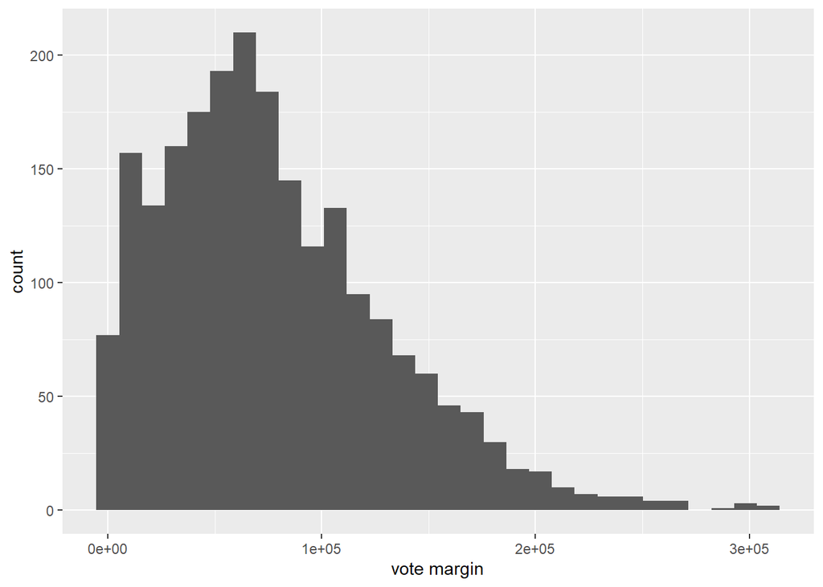

```r
ggplot(margins, aes(x=margin)) +
  geom_histogram() +
  xlab("vote margin")
```

Or, if we want to get fancy, we could create a plot that shows some of the narrowest races and their margins of victory.

```r
margin_recode<-margins|>
  # get the 50 narrowest races
  slice_min(margin, n=50)|>
  # join with the race data
  left_join(races, by=join_by(race_id == id))|>
  # recode so that Dem races are negative numbers and Rep are positive:
  mutate(margin = case_when(`Winning party` == "DEM" ~ margin *-1,
                            `Winning party` == "REP" ~ margin
                            ))|>
  # sort from highest to lowest
  arrange(margin)|>
  # add a sequential row number
  mutate(place = row_number())
```

And then create a color-coded plot showing races and their respective margins:

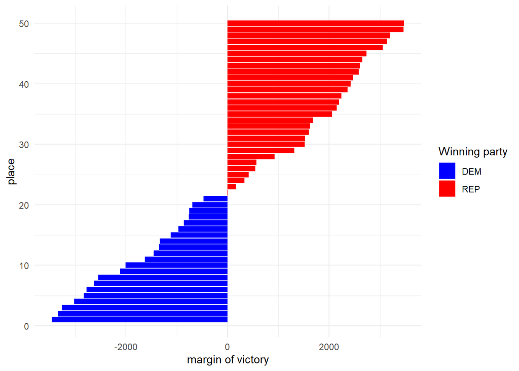

```r
# make a bar plot
ggplot(margin_recode, aes(x=place, y=margin, fill=`Winning party`)) +
  # use the actual values of y as the bar heights
  geom_bar(stat='identity') +
  # add a label
  ylab("margin of victory") +
  # flip it to make the bars horizontal
  coord_flip() +
  # change the theme
  theme_minimal() +
  # change the default coloring:
  scale_fill_manual(values=list("REP" = "red", "DEM"="blue"))
```